# MD 5 HW

# Chapter 5 - Modern Dive

Matthew O’Stricker

We are getting into more complex topics, like how to fit and interpret models. In this section, we will use all the tools we have learned - from wrangling to visualization - to make sure we fit appropriate models and that we understand what these models are doing. Models can be powerful inferential tools but they can also be misleading (like anything). It is important that we know what is powering the machinery we are using so that we always know whether to trust the results we get.

In this homework, we are going to be analyzing twitch data. We will learn a couple of tricks for modeling data along the way.

Let’s begin by loading the data in our usual way.

```r
library(tidyverse)
library(broom)
library(moderndive)
#| message: false
twitch_data <- read_csv("https://raw.githubusercontent.com/vaiseys/dav-course/main/Data/twitchdata-update.csv")
```

The names of th variables here are a bit annoying. They are capitalized and have spaces which makes them awkward to work with in R. Let me show you a neat trick. First, install a package called `janitor` if you don’t have it yet. Then, let’s load it and clean the names.

```r
library(janitor)
twitch_data <- clean_names(twitch_data)

# Inspect new names
colnames(twitch_data)
```

```
 [1] "channel"             "watch_time_minutes"  "stream_time_minutes"
 [4] "peak_viewers"        "average_viewers"     "followers"
 [7] "followers_gained"    "views_gained"        "partnered"
[10] "mature"              "language"
```

[output not shown]

Look at how much better they look. We are ready to begin our analysis.

## Question 1

We will begin with an easy question. An almost obvious question. We are going to examine whether the number of followers a streamer has is predictive of the average viewers they get. Following what the chapter told us, let’s look at the raw data. Show me the `average_viewers` and the `followers` for five random streamers. What do you notice?

```r
twitch_data |>
  select(average_viewers, followers) |>
  sample_n(5)
```

```
# A tibble: 5 × 2
  average_viewers followers
            <dbl>     <dbl>
1           12868   1792625
2            2844    659652
3             297     30413
4           29612   7744066
5           25664   5265659
```

**Answer:**

For the most part, the more `followers` a streamer had was positively correlated to the `average_viewers` they have.

Now, let’s summarize these two variables. An alternative way you get a summary of your variables of interest is by running `summary()` on them. `Select` our two variables of interest and run `summary()`. Describe the results in a few words. Does anything capture your attention?

```r
twitch_data |>
  select(average_viewers, followers) |>
  summary(twitch_data)
```

```
 average_viewers    followers
 Min.   :   235   Min.   :   3660
 1st Qu.:  1458   1st Qu.: 170546
 Median :  2425   Median : 318063
 Mean   :  4781   Mean   : 570054
 3rd Qu.:  4786   3rd Qu.: 624332
 Max.   :147643   Max.   :8938903
```

Okay, lastly - but perhaps most importantly - lets visualize the data. Make a scatterplot with our two variables of interest.

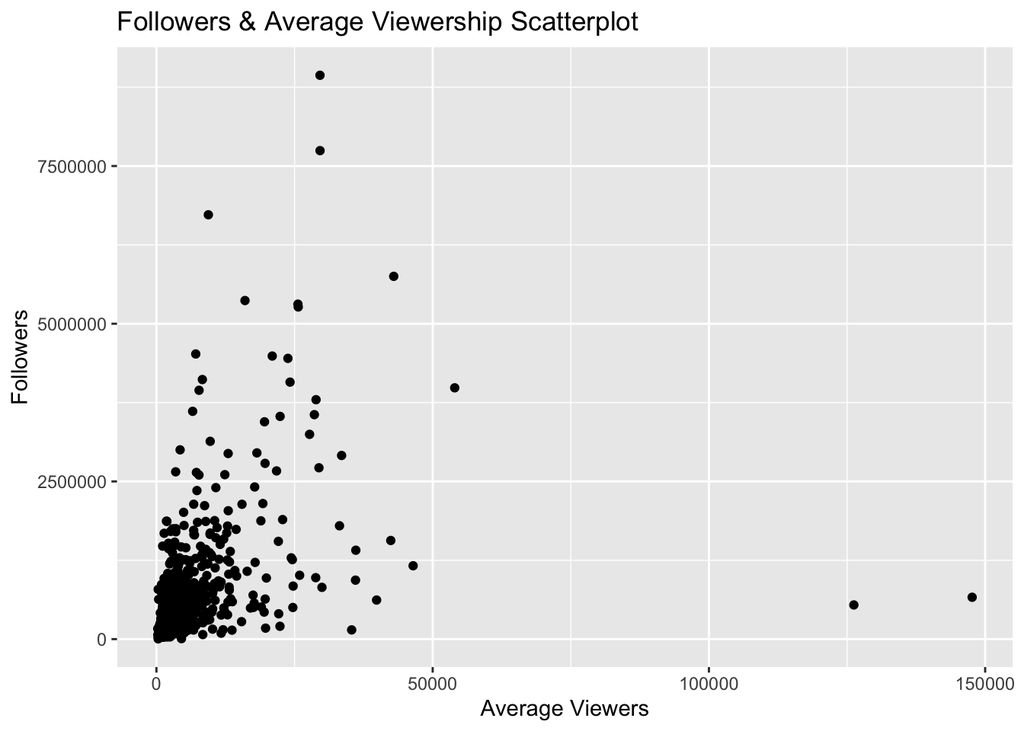

```r
ggplot(twitch_data, aes(x = average_viewers, y = followers)) +
  geom_point() +
  labs(title = "Followers & Average Viewership Scatterplot",
       x = "Average Viewers",
       y = "Followers")
```

What do you notice?

**Answer:**

The data is all packed into the bottom left corner, which is making it extremely hard to analyze the variables of interest.

Right away, you should notice that the data is packed into a small part of the Cartesian plane. Why?

**Answer:**

There is an uneven distribution of the data between the channel followers and average viewers.

Because we have an uneven distribution - a few channels with a lot of followers and a lot of average viewers. So what should we do? We can transform the data. Remember the `scale_x_log10` trick we learned in the last book? Let’s apply it. Make the same plot but adding `scale_x_log10` and `scale_y_log10`. What do you see now? How does the relationship look like?

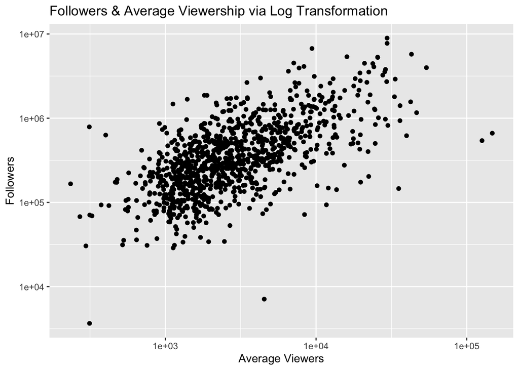

```r
ggplot(twitch_data, aes(x = average_viewers, y = followers)) +
  geom_point() +
  scale_x_log10() +
  scale_y_log10() +
  labs(title = "Followers & Average Viewership via Log Transformation",
       x = "Average Viewers",
       y = "Followers")
```

**Answer:**

A relationship between the two variables looks more apparent in this scenario because the x-axis is now in a logarithmic format and is easier to visualize the data.

Hopefully you have learned something important here: often the relationship between two variables is not immediately obvious and we need to do some transformations of the data to uncover it. Let’s add those transformed variables to our dataset.

```r
twitch_data <- twitch_data %>%
  mutate(log_viewers = log10(average_viewers),
         log_followers = log10(followers))
```

## Question 2

Let’s actually run a regression. Using `lm()` fit a model where you predict the logarithm of average viewers (`log_viewers`) using the logarithm of followers (`log_followers`). Save the results to an object called `fit1`.

```r
fit1 <- lm(log_viewers ~ log_followers, data = twitch_data)

get_regression_table(fit1)
```

```
# A tibble: 2 × 7
  term          estimate std_error statistic p_value lower_ci upper_ci
  <chr>            <dbl>     <dbl>     <dbl>   <dbl>    <dbl>    <dbl>
1 intercept        0.198     0.125      1.58   0.115   -0.048    0.444
2 log_followers    0.588     0.023     26.0    0        0.544    0.633
```

I am going to show you another way of getting a summary of your model. First, let’s install the `broom` package. After, run `tidy()` on your model object (`fit1`).

```r
broom::tidy(fit1)
```

```
# A tibble: 2 × 5
  term          estimate std.error statistic   p.value
  <chr>            <dbl>     <dbl>     <dbl>     <dbl>
1 (Intercept)      0.198    0.125       1.58 1.15e-  1
2 log_followers    0.588    0.0226     26.0  1.69e-114
```

Before I have you describe your results I have to tell you that when you transform your variables, interpretation is a bit different. In the situation we are in - where your outcome and explanatory variables have been logged - the coefficients are interpreted as percentage increases. For example, let’s say we have a coefficient of $0.4$. We would do the following:

$$1.1^{0.4} = 1.03886$$
And we would interpret our coefficient like this:

> A 10% increase in followers is associated with a 3.9% increase in the average number of viewers.

Now, it’s your turn. Take the coefficient from your model and interpret it in this way.

```r
coefficients <- coef(fit1)
print(coefficients)
```

```
  (Intercept) log_followers
    0.1978359     0.5884958
```

## Question 3

Okay, now let’s look at our line of best fit and check the residuals. I am again going to introduce you to an incredibly useful tool from the `broom` package called `augment`. Run the following code:

```r
library(broom)

pred_data <- augment(fit1)

# glimpse our new data
glimpse(pred_data)
```

```
Rows: 1,000
Columns: 8
$ log_viewers   <dbl> 4.442731, 4.408410, 4.040444, 3.887280, 4.471321, 4.6275…
$ log_followers <dbl> 6.511388, 6.725108, 6.247393, 6.596030, 6.951284, 6.1940…
$ .fitted       <dbl> 4.029761, 4.155534, 3.874400, 4.079572, 4.288638, 3.8430…
$ .resid        <dbl> 0.4129697, 0.2528757, 0.1660436, -0.1922928, 0.1826833, …
$ .hat          <dbl> 0.006194481, 0.008694557, 0.003782169, 0.007126066, 0.01…
$ .sigma        <dbl> 0.3085580, 0.3087321, 0.3087919, 0.3087764, 0.3087820, 0…
$ .cooksd       <dbl> 0.0056128779, 0.0029688873, 0.0005513456, 0.0014026033, …
$ .std.resid    <dbl> 1.3420109, 0.8227954, 0.5389316, -0.6251793, 0.5953620, …
```

[output not shown]

Look, it’s our original data but also a bunch more information. The `.fitted` column includes our predictions given our line of best fit. `.resid` contans the residuals. Let’s visualize our line of best fit:

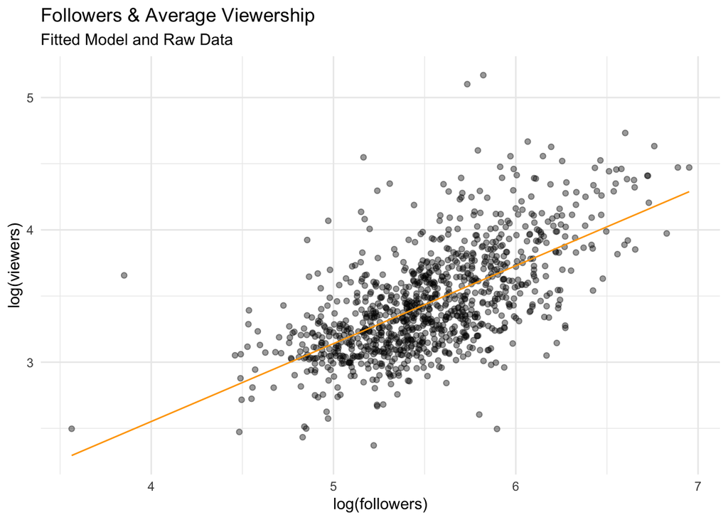

```r
pred_data %>%
  ggplot(aes(x = log_followers,
             y = log_viewers)) +
  geom_jitter(alpha = 0.4) +
  geom_line(aes(x = log_followers, y = .fitted), col = "orange") +
  theme_minimal() +
  labs(subtitle = "Fitted Model and Raw Data",
       title = "Followers & Average Viewership",
       x = "log(followers)",
       y = "log(viewers)")
```

[figure not shown]

Do you think our model describes the relationship well?

**Answer:**

I think that it generally describes the relationship well as there is a high concentration of data points close to the line of best fit.

Now, you fit a plot where `log_followers` is in the x-axis and `.resid` is in the y-axis.

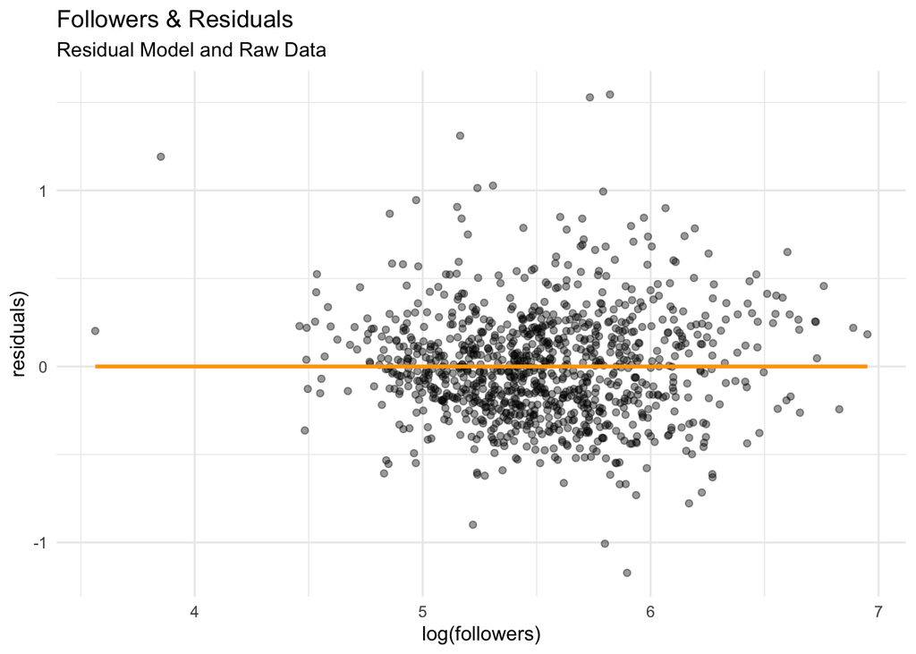

```r
pred_data %>%
  ggplot(aes(x = log_followers,
             y = .resid)) +
  geom_jitter(alpha = 0.4) +
  geom_smooth(method = lm, se = FALSE, col = "orange") +
  theme_minimal() +
  labs(subtitle = "Residual Model and Raw Data",
       title = "Followers & Residuals",
       x = "log(followers)",
       y = "residuals)")
```

What do you see? Are there any big residuals? DO they happen often in a particular range of our x-variable? If so, we would have a problem: our model would systematically fail to predict part of our data.

**Answer:**

I see that this chart is providing a decent visualization of the number of the streamers’ followers from the dataset. There a few big residuals that are sprinkled on the chart like the twitch streamer that is close to the `log(followers)` value of 4.

## Question 4

Let’s now look at regression using one categorical variable to predict one continuous variable. Here, I am interested in whether `language` predicts `average_viewers`. This would give us an indication of where the most popular twitch channels come from. I have a hunch that English streamers might be the most popular. Let’s see.

First, describe our variables of interest as we did above. I am going to give you less guidance here. I want you to explore:

1. The raw data

```r
twitch_data |>
  select(average_viewers, followers) |>
  sample_n(5)
```

```
# A tibble: 5 × 2
  average_viewers followers
            <dbl>     <dbl>
1             728     93991
2            3875   1076499
3             547    105368
4            1052     73584
5            1422    247236
```

```r
twitch_data |>
  group_by(language) |>
  summarize(count = n()) |>
  arrange(desc(count))
```

```
# A tibble: 21 × 2
   language   count
   <chr>      <int>
 1 English      485
 2 Korean        77
 3 Russian       74
 4 Spanish       68
 5 French        66
 6 Portuguese    61
 7 German        49
 8 Chinese       30
 9 Turkish       22
10 Italian       17
# ℹ 11 more rows
```

English is the most used language.

1. Summaries of the variables

```r
twitch_data |>
  select(language, average_viewers) |>
  summary(twitch_data)
```

```
   language         average_viewers
 Length:1000        Min.   :   235
 Class :character   1st Qu.:  1458
 Mode  :character   Median :  2425
                    Mean   :  4781
                    3rd Qu.:  4786
                    Max.   :147643
```

There are 1000 streamers that are tracked using the “`language`” variable and the streamers have an average of 4781 viewers. There is a wide spectrum of “`average_viewers`” though with the lower end being 235 and the higher side being 147643.

1. Plot the variables

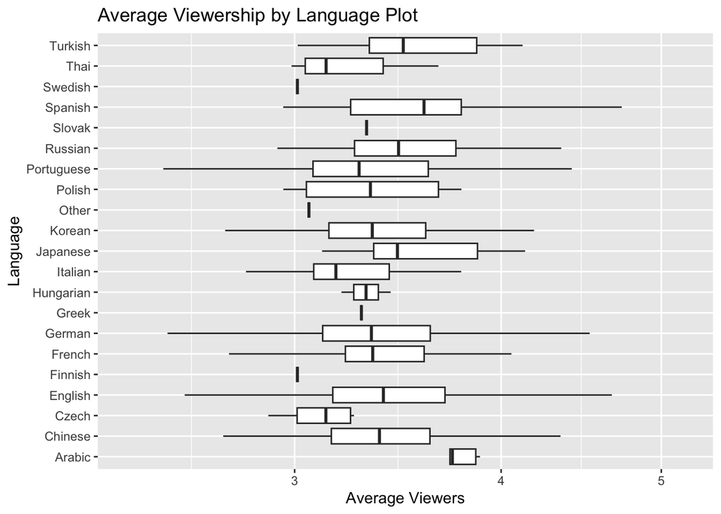

```r
ggplot(twitch_data, aes(x = log_viewers, y = language)) +
  geom_boxplot(outlier.shape = NA) +
  scale_x_log10() +
  labs(title = "Average Viewership by Language Plot",
       x = "Average Viewers",
       y = "Language")
```

**Answer:**

Arabic and Spanish have the highest average viewers out of all the languages. On the lower end of the spectrum were Swedish, Finnish, Thai, and Czech.

## Question 5

Now, we are ready to fit the model. Fit a linear regression where your outcome variable is `average_viewers` and your independent variable is `language`. Let me teach you another trick here. When your categorical variable has many categories it makes sense to establish your reference category *outside of the model*. This ensures that, when you are reading your coefficients, you know what you are comparing them to. Let’s set `English` as our reference category.

```r
twitch_data <- twitch_data %>%
  mutate(language = as.factor(language),
         language = relevel(language, ref = "English"))
```

Now, fit your model. Your coefficients will tell you how many more (or fewer) average viewers are related to streaming in languages different than English. Interpret the results. How is my prediction doing?

```r
fit2 <- lm(average_viewers ~ language, data = twitch_data)

broom::tidy(fit2)
```

```
# A tibble: 21 × 5
   term              estimate std.error statistic  p.value
   <chr>                <dbl>     <dbl>     <dbl>    <dbl>
 1 (Intercept)          5113.      385.    13.3   3.47e-37
 2 languageArabic        569.     3808.     0.150 8.81e- 1
 3 languageChinese     -1688.     1594.    -1.06  2.90e- 1
 4 languageCzech       -3285.     3480.    -0.944 3.45e- 1
 5 languageFinnish     -4086.     8480.    -0.482 6.30e- 1
 6 languageFrench      -1606.     1111.    -1.45  1.49e- 1
 7 languageGerman       -835.     1270.    -0.657 5.11e- 1
 8 languageGreek       -3152.     8480.    -0.372 7.10e- 1
 9 languageHungarian   -2972.     6002.    -0.495 6.21e- 1
10 languageItalian     -2907.     2090.    -1.39  1.65e- 1
# ℹ 11 more rows
```

```r
coefficients <- coef(fit2)
print(coefficients)
```

```
       (Intercept)     languageArabic    languageChinese      languageCzech
         5112.8144           569.3856         -1688.0144         -3285.1478
   languageFinnish     languageFrench     languageGerman      languageGreek
        -4085.8144         -1606.2841          -834.6308         -3151.8144
 languageHungarian    languageItalian   languageJapanese     languageKorean
        -2972.3144         -2907.2850          -350.2144         -1198.9313
     languageOther     languagePolish languagePortuguese    languageRussian
        -3963.8144         -2207.5644         -1311.8800          1481.4153
    languageSlovak    languageSpanish    languageSwedish       languageThai
        -3040.8144          1336.8767         -4085.8144         -3101.4508
   languageTurkish
         -351.9508
```

## Question 6

Explore the residuals here using a similar plot as above. There are a couple of points our model really missed - which ones were they?

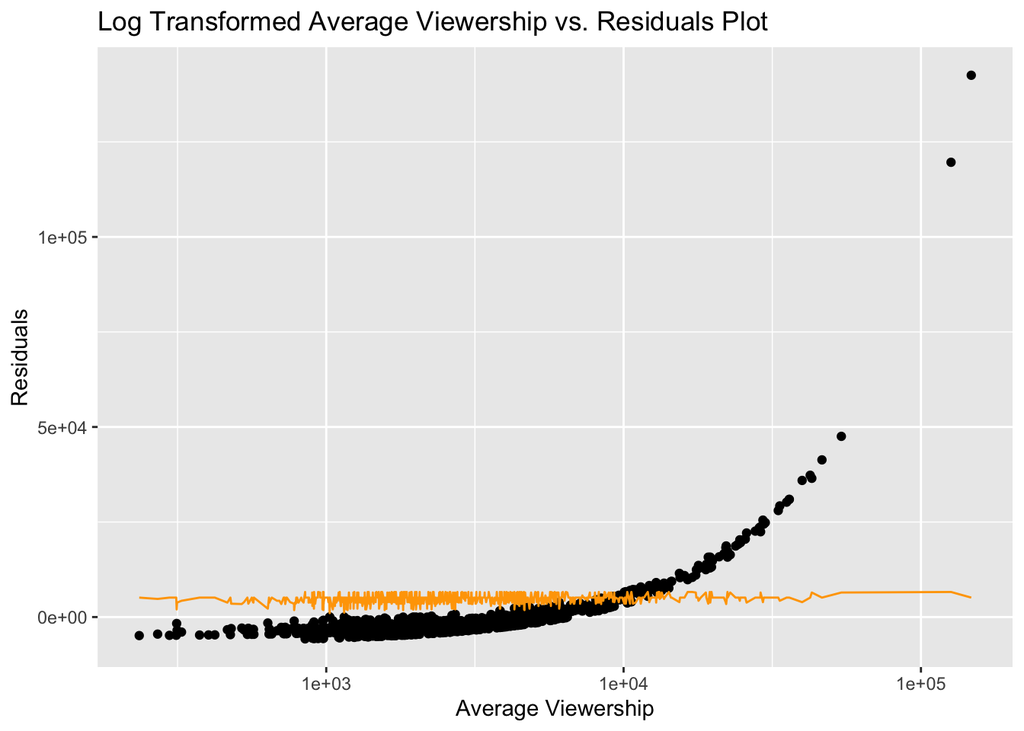

```r
pred_data2 <- augment(fit2)

pred_data2 |>
  ggplot(aes(x = average_viewers,
             y = .resid)) +
  geom_jitter() +
  geom_line(aes(x = average_viewers, y = .fitted), col = "orange") +
  scale_x_log10() +
  labs(title = "Log Transformed Average Viewership vs. Residuals Plot", x = "Average Viewership", y = "Residuals")
```